# Group Assignment Q2

Yang Dun, Ge Weitong, Li Zichang, Wu Hongsheng, Xiang ZiShun

### Book Option Trades

The following analysis is based on a portfolio of long 1000 call options and short delta amount of underlying to make it delta neutral.

It is assumed that we can only trade integer number of shares and there is no transaction cost.

```r
#We assume the portfolio has 1000 call options for ease of hedging.
size <- 1000
# volatility for generating share price, the true volatility
sigma <- 0.4
#implied volatility for pricing call option, which is the market view
imsigma <- 0.3
r <- 0
q <- 0
drift <- r-q
timestep <- 1/250
days=20/250
N <- days/timestep
p1 <- (drift-0.5*sigma**2)*timestep
p2 <- sigma*sqrt(timestep)

#define analytic stats
pnl_pct_error <- c()
pnl_error <- c()
pnl_actual <- c()
sum_gamma_theta_pnl <- c()
overall_profit <- c()
sigma_r <- c()

# repeat the simulation 1000 times
case=1000
i <- 0

repeat{
  #generate random initial price at day 0
  S0 <- runif(1,1,100)
  K <- S0
  #calcualte greeks and call price for end of day0 based on implied volatility and 1000 call options
  vega0  <- GBSGreeks("Vega","c",S=S0,X=K,Time=days,r=r,b=0,sigma=imsigma)
  delta0 <- GBSGreeks("Delta","c",S=S0,X=K,Time=days,r=r,b=0,sigma=imsigma)
  gamma0 <- GBSGreeks("Gamma","c",S=S0,X=K,Time=days,r=r,b=0,sigma=imsigma)
  theta0 <- GBSGreeks("Theta","c",S=S0,X=K,Time=days,r=r,b=0,sigma=imsigma)
  price0 <- GBSOption("c",S=S0,X=K,Time=days,r=r,b=0,sigma=imsigma)@price

  # #calculate initial number of share to sell to neutralize delta
  # hedge_s0 <- -1*round(delta0*size)
  #
  # #calculate the cost of initial portfolio
  # cost <- -1*price0*size

  ####################### simulation

  S_path <- c(S0,rep(S0,N)*c(cumprod(rlnorm(N,mean=p1,sd=p2))))

  Time_series <- tibble(end_of_day=0:20,
                        Tau=seq(days,0,by=-timestep),
                        s_path=S_path)%>%
                 rowwise()%>%
                 #self note: use "=" in mutate, not" <- "
                 #option is priced based on market view of implied volatility
                 mutate(
                    vega  = GBSGreeks("Vega","c",S=s_path,X=K,Time=Tau,r=0,b=0,sigma=imsigma),
                    delta = GBSGreeks("Delta","c",S=s_path,X=K,Time=Tau,r=0,b=0,sigma=imsigma),
                    gamma = GBSGreeks("Gamma","c",S=s_path,X=K,Time=Tau,r=0,b=0,sigma=imsigma),
                    theta = GBSGreeks("Theta","c",S=s_path,X=K,Time=Tau,r=0,b=0,sigma=imsigma),
                    price = GBSOption("c",S=s_path,X=K,Time=Tau,r=r,b=0,sigma=imsigma)@price)%>%
                #self note: need to ungroup after rowwise, otherwise delta_t below will have problem
                ungroup()%>%
                # replace date0's data with initial setting in case sigma is not equal to imsigma
                mutate(
                    # vega  = c(vega0,vega[-1]),
                    # delta = c(delta0,delta[-1]),
                    # gamma = c(gamma0,gamma[-1]),
                    # theta = c(theta0,theta[-1]),
                    # price = c(price0,price[-1]),
                    delta_s=c(0,(s_path-lag(s_path))[-1]),
                    delta_t = c(0,rep(timestep,N)),
                    delta_vol=rep(0,N+1),
                    ##hedge_s is the amount of shares to sell to neutralize delta
                    #hedge_s=-1*floor(delta*size),
                    hedge_s=-1*round(delta*size),

                    #pnl_c1 is the option pnl, pnl_c2 is approximate option pnl
                    #pnl_hedge is the pnl realized by shorting delta amount of shares each day
                    #Pnl are calculated on cumulative basis
                    pnl_c1=cumsum(c(0,size*(price-lag(price))[-1])),
                    pnl_c2=cumsum(c(0,size*(lag(delta)*delta_s+
                                              0.5*lag(gamma)*delta_s**2+lag(vega)*delta_vol+lag(theta)*delta_t)[-1])),
                    pnl_hedge = cumsum(c(0,(lag(hedge_s)*delta_s)[-1])),
                    gamma_theta_pnl=cumsum(c(0,size*(0.5*lag(gamma)*delta_s**2+lag(theta)*delta_t)[-1])),
                    gamma_pnl=c(0,size*(0.5*lag(gamma)*delta_s**2)[-1]),
                    theta_pnl=c(0,size*(lag(theta)*delta_t)[-1]),
                    #debug
                    #test_vega=c(0,size*(lag(vega)*delta_vol)[-1])
                    )  #%>%
                 #calculate implied volatility so as to calculate delta_vol
                 # rowwise()%>%
                 # mutate(IV=GBSVolatility(price,"c",S=s_path,X =K,Time =Tau,r =r,b = 0,tot=0.001,maxiter=500))%>%
                 # ungroup()%>%
                 # mutate(delta_vol=c(0,(IV-lag(IV))[-1]))

  #calculate summary stats.
  pnl_pct_error <- c(pnl_pct_error,100*(Time_series$pnl_c2[nrow(Time_series)]-Time_series$pnl_c1[nrow(Time_series)])/abs(Time_series$pnl_c1[nrow(Time_series)]))


  #difference between estimated pnl and actual pnl
  pnl_error= c(pnl_error,Time_series$pnl_c2[nrow(Time_series)]-Time_series$pnl_c1[nrow(Time_series)])
  #actual pnl
  pnl_actual = c(pnl_actual,Time_series$pnl_c1[nrow(Time_series)])
  sum_gamma_theta_pnl <- c(sum_gamma_theta_pnl,Time_series$gamma_theta_pnl[nrow(Time_series)])
  #sd of the time series
  sigma_r <- c(sigma_r,sd(log(Time_series$s_path/lag(Time_series$s_path))[-1])/sqrt(timestep))
  #overall profit of portfolio at day 20
  overall_profit <- c(overall_profit,-1*size*price0+
                                     #size*max(0,Time_series$price[nrow(Time_series)])+
                                     size*max(0,Time_series$s_path[nrow(Time_series)]-Time_series$s_path[1])+
                                     Time_series$pnl_hedge[nrow(Time_series)])

  ###debug to see the detail of extreme case
  # if(abs(100*(Time_series$pnl_c2[nrow(Time_series)]-Time_series$pnl_c1[nrow(Time_series)])/abs(Time_series$pnl_c1[nrow(Time_series)]))>400   #)
  # {
  #   break
  # }

  i=i+1
  if(i==case){
    break
    }
}
# debug
# summary <- tibble(trial=1:(i+1),#case,
 summary <- tibble(trial=1:case,
                  pnl_error_pct=pnl_pct_error,
                  pnl_error=pnl_error,
                  pnl_actual= pnl_actual,
                  sigma_actual=sigma_r,
                  total_profit=overall_profit,
                  sum_gamma_theta_pnl=sum_gamma_theta_pnl)
```

### Point 1

It is also noted that there are several outliers due to high realized volatility, or large price swings, in those simulation cases.

The median of the total error (sum of 20 days) is 0.1089135% of the actual PnL, the average of total error is -13.4891206% of the actual PnL.

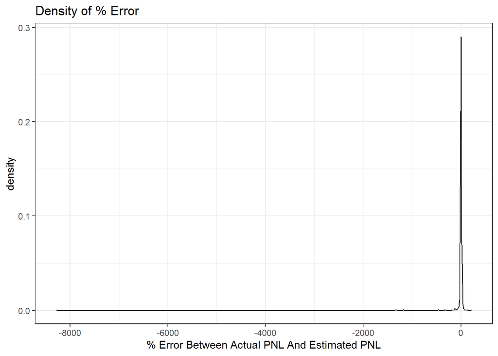

```r
ggplot(summary,aes(pnl_pct_error))+geom_density()+
              scale_x_continuous(name = "% Error Between Actual PNL And Estimated PNL")+
              ggtitle("Density of % Error")+theme_bw()
```

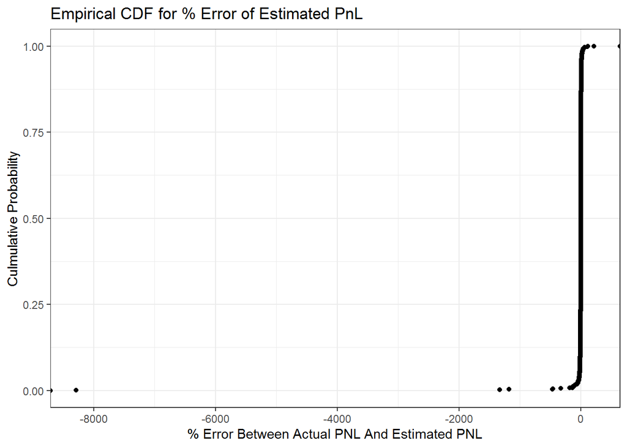

```r
#boxplot
# ggplot(summary,aes(pnl_pct_error))+geom_boxplot()

ggplot(summary,aes(pnl_pct_error))+stat_ecdf(geom="point")+
              scale_x_continuous(name = "% Error Between Actual PNL And Estimated PNL")+
              scale_y_continuous(name = "Culmulative Probability")+
              ggtitle("Empirical CDF for % Error of Estimated PnL")+theme_bw()
```

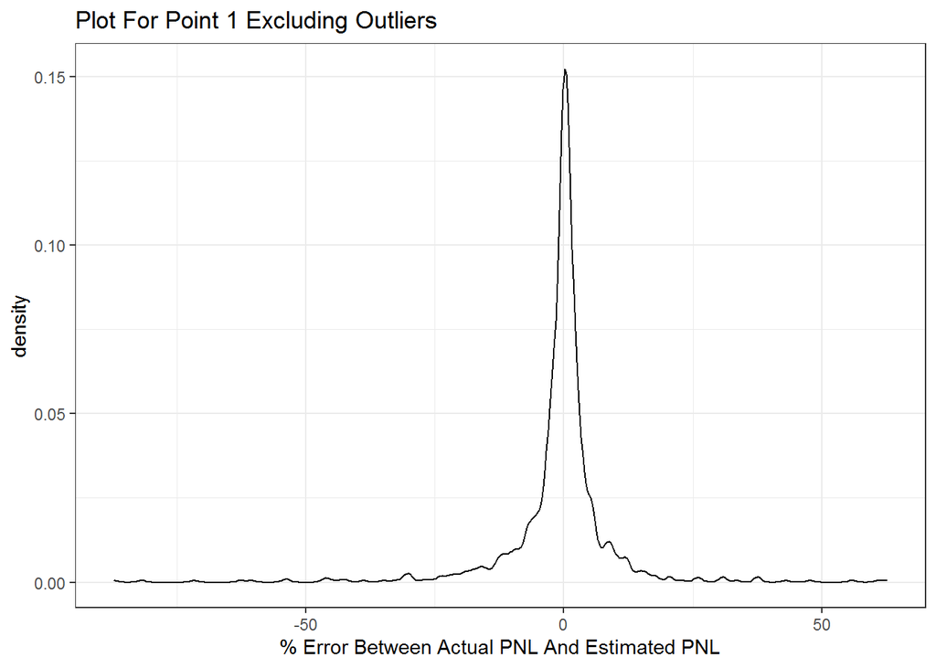

```r
#density exclude outlier
ggplot(data=summary%>%filter(abs(pnl_pct_error)<100))+geom_density(aes(pnl_error_pct))+
              scale_x_continuous(name = "% Error Between Actual PNL And Estimated PNL")+
              ggtitle("Plot For Point 1 Excluding Outliers")+theme_bw()
```

### Point 2

The Chart 2.1 below plots the sum of Gamma pnl and Theta Pnl per contract (Y axis) against the absolute value of difference between realized vol and implied vol (X axis). It shows that when X approaches zero, Y tends to zero as well.

The chart 2.2 is a zoom-in of chart 2.1 showing that when the absolute difference betweeen realized volatility and implied volatility becomes very small (<1%), the sum of gamma and theta PnL also becomes very small (despite some small deviations from zero).

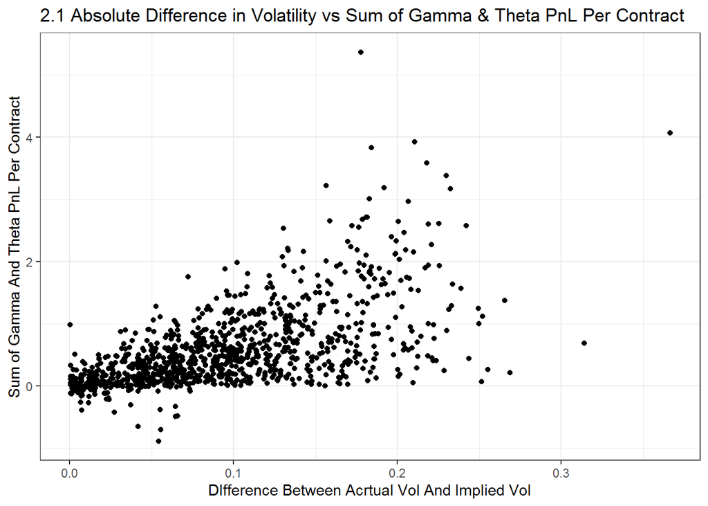

```r
ggplot(data=mutate(summary,sigma_dif=abs(sigma_actual-imsigma)),aes(sigma_dif,sum_gamma_theta_pnl/size))+geom_point()+
              scale_x_continuous(name = "DIfference Between Acrtual Vol And Implied Vol")+
              scale_y_continuous(name = "Sum of Gamma And Theta PnL Per Contract")+
              ggtitle("2.1 Absolute Difference in Volatility vs Sum of Gamma & Theta PnL Per Contract")+theme_bw()
```

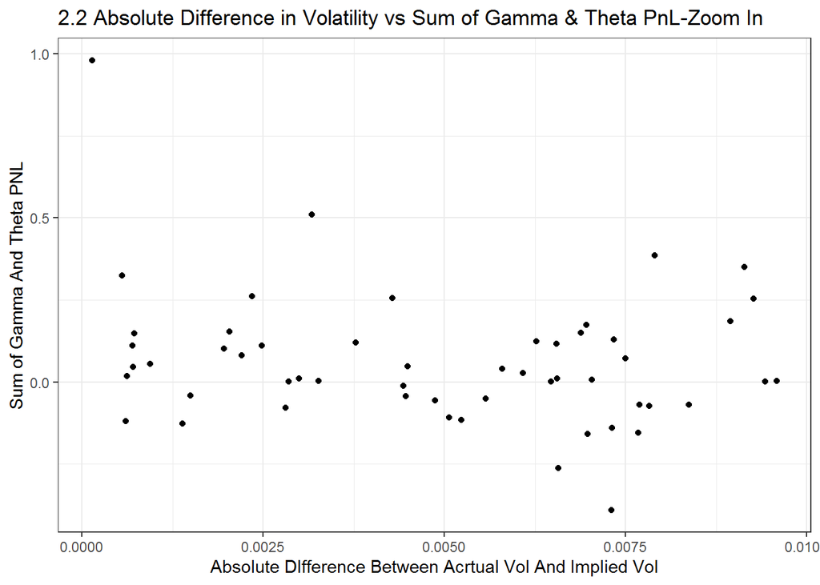

```r
# take a closer look
ggplot(data=summary%>%mutate(sigma_dif=abs(sigma_actual-imsigma))%>%filter(sigma_dif<0.01),aes(sigma_dif,sum_gamma_theta_pnl/size))+geom_point()+
              scale_x_continuous(name = "Absolute DIfference Between Acrtual Vol And Implied Vol")+
              scale_y_continuous(name = "Sum of Gamma And Theta PNL")+
              ggtitle("2.2 Absolute Difference in Volatility vs Sum of Gamma & Theta PnL-Zoom In")+theme_bw()
```

### Point 3

The plot below shows that when realized volatility is larger than the implied volatility, we have higher probability of gaining a positive profit.

On the other hand, we are more likely to suffer a loss if actual volatility is lower than the implied volatility.

There are some points falling into the second and fourth quarter due to imperfect hedging and possibly small rounding errors.

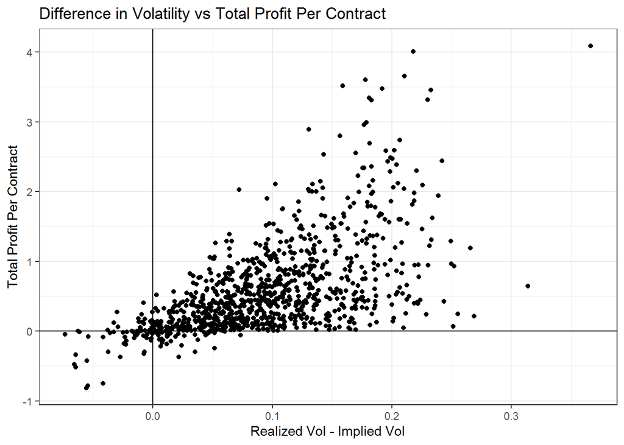

```r
ggplot(data=summary%>%mutate(sigma_df=sigma_actual-imsigma),aes(sigma_df,total_profit/size))+geom_point()+
                                  geom_vline(xintercept = 0)+geom_hline(yintercept = 0)+
                                  scale_x_continuous(name="Realized Vol - Implied Vol")+
                                  scale_y_continuous(name="Total Profit Per Contract")+
                                  ggtitle("Difference in Volatility vs Total Profit Per Contract")+theme_bw()
```